I. Reading in the data

```r
fhs.df <- read.csv('framingham.csv')
#fhs.df[ 1:10, 1:16 ]
fhs.df
```

[output not shown]

[output cut: 12708 more lines]

## dimension of the matrix

```r
dim( fhs.df )
```

```
## [1] 4240   16
```

There are 4240 subjects.

## variable names

```r
# what are the variable names
names( fhs.df )
```

```
##  [1] "male"            "age"             "education"       "currentSmoker"
##  [5] "cigsPerDay"      "BPMeds"          "prevalentStroke" "prevalentHyp"
##  [9] "diabetes"        "totChol"         "sysBP"           "diaBP"
## [13] "BMI"             "heartRate"       "glucose"         "TenYearCHD"
```

## attach dataset

```r
# link to dataset
attach( fhs.df )
```

# II. Model building

We will start with a forward selection strategy first. If this does not lead to the model with the best goodness of fit, we will consider alternative model along the way.

The variables we have are :

```
  sex, age

  Education

  CurrentSmoker, cigsPerday, heartRate

  PrevalentStroke, prevalentHyp, BPMeds

  diabetes

  glucose, totChol, BMI
```

We will build a simple linear model for the our defined response variable, using only the explanatory variables (or functions of them):

```
  CurrentSmoker, cigsPerday
```

Once we have a model in term of these two confounding confounding variables, we will add:

```
  BPMeds
```

## - response variable

Blood pressure is an health measure of cardiovascular function. In general, high blood pressure indicates poor vascular health, and lower blood pressure indicates otherwise. The ideal blood pressure reading is less than 120/80 mmHg.

General guidelines:

Normal: less than 120/80 mmHg

Elevated: 120/129 / <80 mmHg

Hypertension status 1: 130-139 / 80-90 mmHg

Hypertension status 2: 140 or higher / 90 or higher mmHg

we decide to make our response variable as the difference between of the systolic blood pressure and the diastolic blood pressure.

When blood pressure is taken, systolic and diastolic blood pressures are measured.

```
  1. Systolic pressure (the top number in the blood pressure reading) measures the pressure of the arteries when the heart push the oxygenated blood out into the circulatory system during the contraction phase.

  2. Dystolic pressure (the bottom number in the blood pressure reading) measures the pressure of the arteries in between contraction, when the heart is at the relaxation phase.
```

```r
# define the difference bet. systolic and dystolic pressure
bpd = sysBP - diaBP
#bp.df

# create the log.bpd variable
log.bpd = log(bpd)
```

## - age model

Does age has to do with cardiovascular health?

In theory, yes, because age is a risk factor for age-related cardiovascular declines.

```r
age.model <- lm ( log.bpd ~ age )
summary( age.model )
```

```
##
## Call:
## lm(formula = log.bpd ~ age)
##
## Residuals:
##      Min       1Q   Median       3Q      Max
## -1.01065 -0.16238 -0.00306  0.15327  1.01834
##
## Coefficients:
##              Estimate Std. Error t value Pr(>|t|)
## (Intercept) 3.1912082  0.0225468  141.54   <2e-16 ***
## age         0.0135254  0.0004481   30.18   <2e-16 ***
## ---
## Signif. codes:  0 '***' 0.001 '**' 0.01 '*' 0.05 '.' 0.1 ' ' 1
##
## Residual standard error: 0.2501 on 4238 degrees of freedom
## Multiple R-squared:  0.1769, Adjusted R-squared:  0.1767
## F-statistic:   911 on 1 and 4238 DF,  p-value: < 2.2e-16
```

```r
anova( age.model )
```

```
## Analysis of Variance Table
##
## Response: log.bpd
##             Df  Sum Sq Mean Sq F value    Pr(>F)
## age          1  56.993  56.993  911.04 < 2.2e-16 ***
## Residuals 4238 265.122   0.063
## ---
## Signif. codes:  0 '***' 0.001 '**' 0.01 '*' 0.05 '.' 0.1 ' ' 1
```

### plot

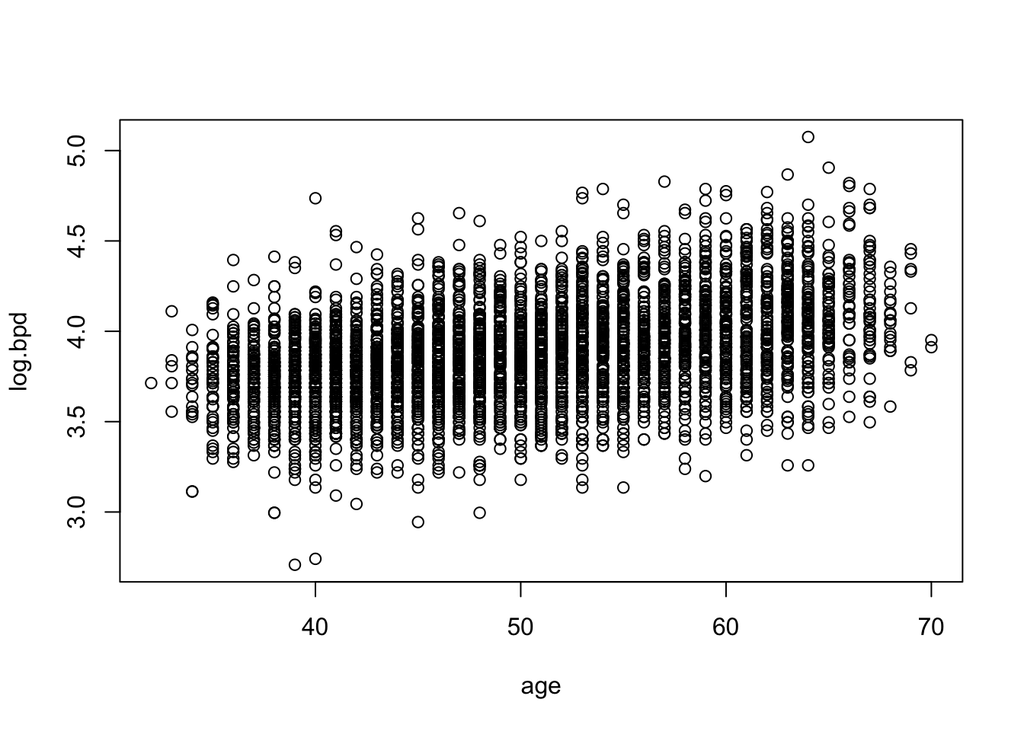

```r
plot( age, log.bpd )
```